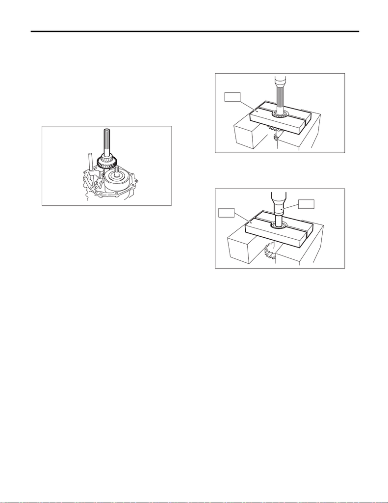

6MT(TY85)-54

Transfer Driven Gear

MANUAL TRANSMISSION AND DIFFERENTIAL

16.Transfer Driven Gear

A: REMOVAL

1) Remove the manual transmission assembly

from the vehicle. <Ref. to 6MT(TY85)-31, REMOV-

AL, Manual Transmission Assembly.>

2) Prepare the transmission for overhaul. <Ref. to

6MT(TY85)-38, Preparation for Overhaul.>

3) Remove the extension case. <Ref. to

6MT(TY85)-42, REMOVAL, Extension Case.>

4) Remove the transfer driven gear.

B: INSTALLATION

1) Install the transfer driven gear.

CAUTION:

Apply transmission gear oil onto sliding or re-

volving surfaces before installation.

2) When the bearing or the transfer driven gear is

replaced, select an appropriate adjusting washer

for the transfer driven gear. <Ref. to 6MT(TY85)-

44, ADJUSTMENT, Extension Case.>

3) Install the extension case. <Ref. to 6MT(TY85)-

42, INSTALLATION, Extension Case.>

4) Install the manual transmission assembly to the

vehicle. <Ref. to 6MT(TY85)-33, INSTALLATION,

Manual Transmission Assembly.>

C: DISASSEMBLY

1) Using the ST, remove the taper roller bearing

(extension case side).

ST 498515700 REMOVER

2) Using the ST, remove the taper roller bearing

(transmission case side).

ST1 899858600 REMOVER

ST2 899864100 REMOVER

MT-00951

MT-00511

ST

MT-00512

ST2

ST1

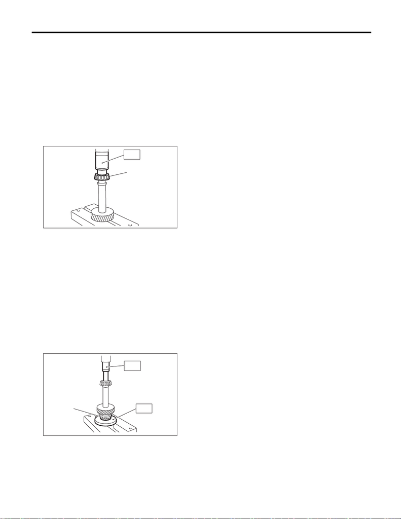

6MT(TY85)-55

Transfer Driven Gear

MANUAL TRANSMISSION AND DIFFERENTIAL

D: ASSEMBLY

1) Using the ST, install the taper roller bearing

(transmission case side).

ST 499757002 INSTALLER

CAUTION:

• Do not apply pressure in excess of 10 kN (1

ton, 1.1 US ton, 1.0 Imp ton).

• Apply transmission gear oil onto sliding or

revolving surfaces before installation.

NOTE:

Be careful when handling because the taper roller

bearing and the outer race are used as a set.

2) Using the ST, install the taper roller bearing (ex-

tension case side).

ST1 398177700 INSTALLER

ST2 899864100 REMOVER

CAUTION:

• Do not apply pressure in excess of 10 kN (1

ton, 1.1 US ton, 1.0 Imp ton).

• Apply transmission gear oil onto sliding or

revolving surfaces before installation.

NOTE:

Be careful when handling because the taper roller

bearing and the outer race are used as a set.

E: INSPECTION

1) Bearing

Replace the bearings in the following cases.

• Damage or rust on the bearings

• Wear or damage

• After applying transmission gear oil, bearing

does not rotate smoothly or an abnormal noise is

emitted.

2) Driven gear

Replace the driven gear in the following cases.

• If the driven gear tooth surface and shaft are ex-

cessively damaged or broken.

(A) Taper roller bearing (transmission case side)

(A) Taper roller bearing (extension case side)

MT-00514

(A)

ST

MT-00513

(A)

ST1

ST2